# 3_reddit_NLP

## 📢 Reddit NLP Analysis: How People Really Talk About Aesthetics, PEDs, and Fitness Pressure

In this notebook, we explore **Reddit discussions** to analyze public opinion, fears, and rationalizations surrounding:

- SARMs
- Steroids
- Natural vs enhanced physiques
- Mental and physical side effects
- Health vs aesthetics debate

This qualitative lens complements our previous quantitative findings by giving us **insight into lived experiences and public attitudes.**

```python
import praw
import pandas as pd
from datetime import datetime


reddit = praw.Reddit(
    client_id='ejRr8K5Y-W-OwyL3U508ew',
    client_secret='G_1zYLqze_g1EogxK8p-2LcAi_-x9g',
    user_agent='sarms_scraper by u/rohitananth',
)

# ✅ Keywords & subreddit
search_query = "sarms OR steroids OR tren OR ostarine OR shredded OR natty"
subreddit_names = ["Fitness", "moreplatesmoredates", "bodybuilding", "nattyorjuice"]  # List of subreddits to query

# 🔄 Fetch posts
posts = []
for subreddit_name in subreddit_names:
    for submission in reddit.subreddit(subreddit_name).search(search_query, limit=500, sort='new'):
        posts.append({
            'title': submission.title,
            'text': submission.selftext,
            'score': submission.score,
            'created': datetime.utcfromtimestamp(submission.created_utc),
            'num_comments': submission.num_comments,
            'url': submission.url,
        })

# 📁 Convert to DataFrame
reddit_df = pd.DataFrame(posts)
reddit_df.to_csv("../data/reddit_posts_raw.csv", index=False)
reddit_df.head()
```

```
Version 7.7.1 of praw is outdated. Version 7.8.1 was released Friday October 25, 2024.
```

|  | title | text | score | created | num_comments | url |
| --- | --- | --- | --- | --- | --- | --- |
| 0 | 2,000 Workouts Without a Rest Day | This is another update about training without ... | 591 | 2024-10-16 17:08:37 | 137 | https://www.reddit.com/r/Fitness/comments/1g54... |
| 1 | Five Years Without a Rest Day | Hello, /u/gzcl here with another post about tr... | 684 | 2024-03-26 15:50:23 | 251 | https://www.reddit.com/r/Fitness/comments/1bob... |
| 2 | Progress Post: 7 Years of Showing Up, Asking Q... | ## Summary\n\nA former skinny kid starts lifti... | 195 | 2023-04-14 00:02:02 | 43 | https://www.reddit.com/r/Fitness/comments/12lc... |
| 3 | 18M Natural Transformation (Skinny to Muscle) | **Before:** age 18, 5' 11'', 135 pounds\n\n**A... | 952 | 2023-01-04 23:21:21 | 162 | https://www.reddit.com/r/Fitness/comments/103i... |
| 4 | Here's 70 pages of notes I've taken from 20+ p... | [4 years ago I submitted a series of fitness, ... | 1560 | 2022-07-26 16:10:07 | 159 | https://www.reddit.com/r/Fitness/comments/w8nq... |

```python
reddit_df['full_text'] = reddit_df['title'].fillna('') + ' ' + reddit_df['text'].fillna('')
reddit_df['full_text'] = reddit_df['full_text'].str.replace(r'http\S+|www\S+|https\S+', '', case=False, regex=True)
```

```python
import spacy

# Download the English model
!python -m spacy download en_core_web_sm
```

```
  Using cached https://github.com/explosion/spacy-models/releases/download/en_core_web_sm-3.8.0/en_core_web_sm-3.8.0-py3-none-any.whl (12.8 MB)
✔ Download and installation successful
You can now load the package via spacy.load('en_core_web_sm')
```

```python
import spacy
import re

# Load English tokenizer, POS tagger, parser, NER and word vectors
nlp = spacy.load("en_core_web_sm")

# Function to clean and preprocess each post
def preprocess_text(text):
    # Remove URLs, mentions, punctuation, digits
    text = re.sub(r"http\S+|www\S+|@\w+|[^A-Za-z\s]", " ", text)
    text = re.sub(r"\s+", " ", text)  # Remove extra whitespace

    doc = nlp(text.lower().strip())

    tokens = [
        token.lemma_ for token in doc
        if not token.is_stop and not token.is_punct and token.is_alpha and len(token) > 2
    ]

    return " ".join(tokens)

# Combine title and body into one column (if not already done)
reddit_df['full_text'] = reddit_df['title'].fillna('') + ' ' + reddit_df['text'].fillna('')

# Apply preprocessing
reddit_df['clean_text'] = reddit_df['full_text'].apply(preprocess_text)

# Preview cleaned text
reddit_df[['title', 'clean_text']].head()
```

|  | title | clean_text |
| --- | --- | --- |
| 0 | 2,000 Workouts Without a Rest Day | workout rest day update training rest day surp... |
| 1 | Five Years Without a Rest Day | year rest day hello gzcl post training rest da... |
| 2 | Progress Post: 7 Years of Showing Up, Asking Q... | progress post year show ask question try hard ... |
| 3 | 18M Natural Transformation (Skinny to Muscle) | natural transformation skinny muscle age pound... |
| 4 | Here's 70 pages of notes I've taken from 20+ p... | page note take podcast interview seminar lead ... |

```python
from collections import Counter
from wordcloud import WordCloud
import matplotlib.pyplot as plt
import seaborn as sns

# Tokenize cleaned text into individual words
all_words = " ".join(reddit_df['clean_text']).split()

# Count word frequencies
word_freq = Counter(all_words)
common_words = word_freq.most_common(30)
```

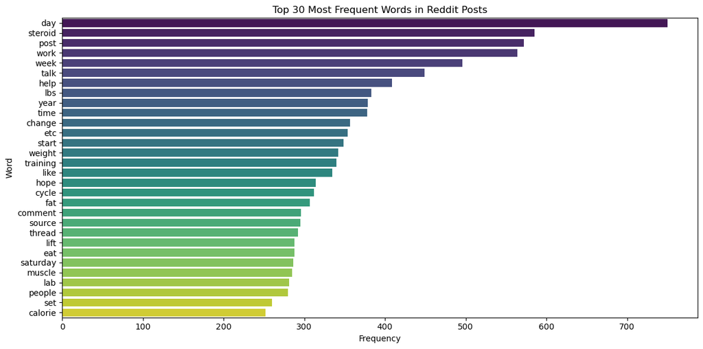

```python
# --- Plot 1: Word Frequency Bar Plot ---
words, counts = zip(*common_words)
plt.figure(figsize=(12, 6))
sns.barplot(x=list(counts), y=list(words), palette='viridis')
plt.title("Top 30 Most Frequent Words in Reddit Posts")
plt.xlabel("Frequency")
plt.ylabel("Word")
plt.tight_layout()
plt.savefig("../visuals/reddit_top_words.png")
plt.show()
```

## 📊 Top 30 Most Frequent Words in Reddit Fitness Posts

This bar chart shows the most commonly used words in Reddit threads related to fitness, aesthetics, and PED use.

### 🔍 Interpretation:

> Redditors aren’t just sharing workouts — they’re wrestling with identity, self-worth, and whether or not to enhance themselves artificially.

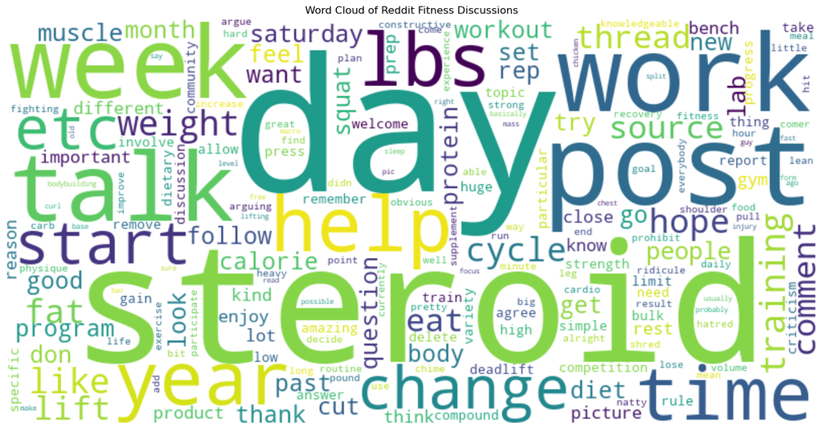

```python
# --- Plot 2: Word Cloud ---
wordcloud = WordCloud(width=800, height=400, background_color='white').generate_from_frequencies(word_freq)
plt.figure(figsize=(14, 7))
plt.imshow(wordcloud, interpolation='bilinear')
plt.axis('off')
plt.title("Word Cloud of Reddit Fitness Discussions")
plt.tight_layout()
plt.savefig("../visuals/reddit_wordcloud.png")
plt.show()
```

## ☁️ Word Cloud: Lexicon of Modern Fitness Culture on Reddit

### 💡 Key Insight:

> This isn’t just fitness advice — it’s fitness storytelling.

The Reddit community uses a vocabulary of struggle, enhancement, help-seeking, and identity-shaping.  
The word cloud gives us a **bird’s-eye view of the psychological landscape**: aspirations, methods, and internal conflict, all embedded in the choice of words.

Next, we’ll quantify these emotional patterns through **sentiment analysis** — to uncover how people actually *feel* about what they’re posting.

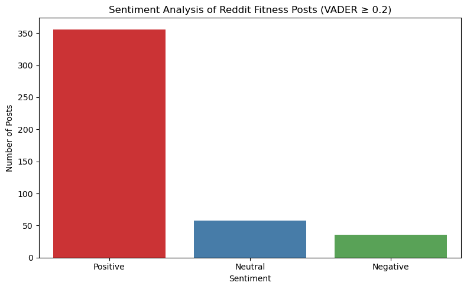

```python
from vaderSentiment.vaderSentiment import SentimentIntensityAnalyzer

# Reinitialize VADER
analyzer = SentimentIntensityAnalyzer()

# Apply sentiment scoring again
reddit_df['sentiment_score'] = reddit_df['clean_text'].apply(lambda text: analyzer.polarity_scores(text)['compound'])


from textblob import TextBlob

# --- 1. VADER sentiment classification ---
def classify_sentiment_strict(score):
    if score >= 0.2:
        return 'Positive'
    elif score <= -0.2:
        return 'Negative'
    else:
        return 'Neutral'

reddit_df['sentiment_strict'] = reddit_df['sentiment_score'].apply(classify_sentiment_strict)

# --- 2. TextBlob sentiment scores ---
reddit_df['textblob_polarity'] = reddit_df['clean_text'].apply(lambda x: TextBlob(str(x)).sentiment.polarity)
reddit_df['textblob_subjectivity'] = reddit_df['clean_text'].apply(lambda x: TextBlob(str(x)).sentiment.subjectivity)

# --- 3. Sentiment vs Common Keywords (manually curated) ---
keywords = ['hope', 'help', 'regret', 'side', 'effect', 'cycle', 'natty', 'progress', 'anxiety', 'gain']
keyword_sentiment = {}

for word in keywords:
    mask = reddit_df['clean_text'].str.contains(word, na=False)
    sentiment_dist = reddit_df[mask]['sentiment_strict'].value_counts(normalize=True)
    keyword_sentiment[word] = sentiment_dist

# Convert keyword-sentiment mapping to DataFrame
import pandas as pd
keyword_sentiment_df = pd.DataFrame(keyword_sentiment).fillna(0).T
keyword_sentiment_df = keyword_sentiment_df[['Positive', 'Neutral', 'Negative']]  # ensure column order

import matplotlib.pyplot as plt
import seaborn as sns

# --- Plot updated sentiment distribution ---
plt.figure(figsize=(8, 5))
sns.countplot(data=reddit_df, x='sentiment_strict', palette='Set1', order=['Positive', 'Neutral', 'Negative'])
plt.title("Sentiment Analysis of Reddit Fitness Posts (VADER ≥ 0.2)")
plt.xlabel("Sentiment")
plt.ylabel("Number of Posts")
plt.tight_layout()
plt.savefig("../visuals/reddit_sentiment_strict.png")
plt.show()
```

## 🎭 Sentiment Analysis of Reddit Fitness Posts

Using a sentiment classifier designed for social media, we analyzed how users emotionally express themselves in fitness-related Reddit posts.

### 🔍 Key Findings:

- The majority of posts convey a **positive emotional tone**, often rooted in personal progress, shared advice, and community support.
- **Neutral posts** typically consist of technical questions or direct updates — with little emotional charge.
- A noticeable portion of **negative sentiment** posts exists, often tied to confusion, frustration, or consequences of extreme decisions like PED use.

### 🧠 Takeaway:

> Despite underlying risks and body image pressures, the fitness discourse on Reddit is largely **driven by motivation and community reinforcement**, with emotional lows surfacing in more vulnerable posts.

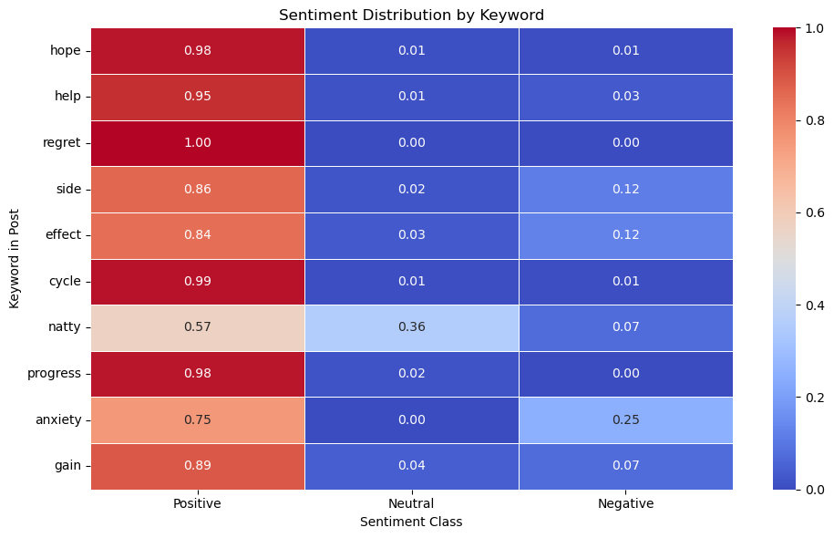

```python
# --- Plot: Heatmap of Sentiment by Keyword ---
plt.figure(figsize=(10, 6))
sns.heatmap(keyword_sentiment_df, annot=True, cmap='coolwarm', fmt=".2f", linewidths=0.5)
plt.title("Sentiment Distribution by Keyword")
plt.xlabel("Sentiment Class")
plt.ylabel("Keyword in Post")
plt.tight_layout()
plt.savefig("../visuals/reddit_keyword_sentiment_heatmap.png")
plt.show()
```

## 🔥 Emotional Context Behind Key Fitness Terms

This heatmap shows how sentiment varies depending on the presence of specific high-impact words in Reddit fitness discussions.

### 🧠 Why It Matters:

> **The emotional weight behind these words matters more than their literal meaning**.

Reddit users often process complex experiences — from transformation to breakdown — through emotionally charged but seemingly neutral terms. This layer of analysis helps decode the **unspoken narrative beneath the physique-first culture**.

```python
from sklearn.feature_extraction.text import CountVectorizer
from sklearn.decomposition import LatentDirichletAllocation

# Vectorize the text data
vectorizer = CountVectorizer(max_df=0.95, min_df=5, stop_words='english')
doc_term_matrix = vectorizer.fit_transform(reddit_df['clean_text'])

# Fit the LDA model
lda_model = LatentDirichletAllocation(n_components=5, random_state=42, learning_method='batch')
lda_model.fit(doc_term_matrix)

# Extract topic words
def display_topics(model, feature_names, num_top_words):
    topics = []
    for topic_idx, topic in enumerate(model.components_):
        top_words = [feature_names[i] for i in topic.argsort()[:-num_top_words - 1:-1]]
        topics.append((f"Topic #{topic_idx + 1}", top_words))
    return topics

# Show top words for each topic
num_top_words = 10
feature_names = vectorizer.get_feature_names_out()
lda_topics = display_topics(lda_model, feature_names, num_top_words)

import pandas as pd
lda_topics_df = pd.DataFrame([(t[0], ", ".join(t[1])) for t in lda_topics], columns=["Topic", "Top Keywords"])
from IPython.display import display

# Display the dataframe in the notebook
display(lda_topics_df)
```

|  | Topic | Top Keywords |
| --- | --- | --- |
| 0 | Topic #1 | steroid, post, talk, thread, comment, cycle, c... |
| 1 | Topic #2 | muscle, supplement, bodybuilding, testosterone... |
| 2 | Topic #3 | lbs, set, day, start, squat, weight, bench, pr... |
| 3 | Topic #4 | day, training, time, program, year, rest, work... |
| 4 | Topic #5 | week, fat, eat, day, calorie, diet, cut, like,... |

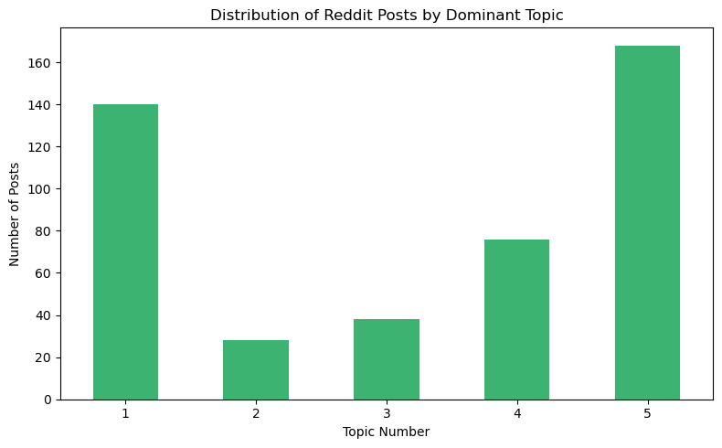

```python
# Assign each post its dominant topic
doc_topic_dist = lda_model.transform(doc_term_matrix)
reddit_df['Dominant_Topic'] = doc_topic_dist.argmax(axis=1) + 1  # Add 1 for human readability (Topic 1, 2, ...)

# Count posts per topic
topic_counts = reddit_df['Dominant_Topic'].value_counts().sort_index()

# Plot the results
import matplotlib.pyplot as plt

plt.figure(figsize=(8, 5))
topic_counts.plot(kind='bar', color='mediumseagreen')
plt.title("Distribution of Reddit Posts by Dominant Topic")
plt.xlabel("Topic Number")
plt.ylabel("Number of Posts")
plt.xticks(rotation=0)
plt.tight_layout()
plt.savefig("../visuals/lda_topic_distribution.png")
plt.show()
```

## 🧠 Topic Modeling: What Are Redditors *Really* Talking About?

We applied **Latent Dirichlet Allocation (LDA)** — a powerful unsupervised NLP method — to uncover recurring themes in Reddit’s fitness discussions.

Each “topic” here is a hidden pattern of word co-occurrence, showing us what types of conversations dominate the subreddit.

### 🔍 Discovered Themes:

#### 📌 **Topic 1: Steroid Use & Cycle Discussion**

- *Keywords:* steroid, post, talk, thread, comment, cycle
- **Focus:** Real-world PED usage, sourcing, side effects, and user commentary. This is the raw nerve of enhancement culture.

#### 📌 **Topic 2: Supplements & Muscle Building**

- *Keywords:* muscle, supplement, testosterone, gym, strength
- **Focus:** Optimizing growth with over-the-counter enhancers. Testosterone and legal alternatives dominate.

#### 📌 **Topic 3: Strength Training Fundamentals**

- *Keywords:* lbs, set, squat, weight, bench, press
- **Focus:** Classic compound lifts, progressive overload, and gym milestones — the practical backbone of lifting.

#### 📌 **Topic 4: Programming & Consistency**

- *Keywords:* day, training, time, program, rest, work
- **Focus:** Building routines, managing fatigue, recovery strategies, and daily grind of staying consistent.

#### 📌 **Topic 5: Cutting, Nutrition, & Fat Loss**

- *Keywords:* week, fat, eat, calorie, diet, cut
- **Focus:** Shredding, meal plans, weight management. This is where aesthetics and discipline intersect.

## 📊 Topic Popularity Breakdown

To understand what resonates most with users, we assigned each post its **dominant topic** and visualized their distribution.

### 📈 Key Observations:

- **Topic 5 (Cutting, Diet, Fat Loss)** is the most dominant — reflecting the community's **obsession with leanness, aesthetics, and caloric control**.
- **Topic 1 (Steroid Use & Enhancement Talk)** is a close second, emphasizing how **normalized and active PED discussions have become**.
- **Topic 4 (Training & Routine)** shows sustained interest in long-term discipline, recovery, and programming.
- **Topics 2 and 3**, while present, appear more **niche or technical** — appealing to fewer users despite being fundamental.

### 🧠 Why It Matters:

> **Fitness discourse today isn’t driven by health or strength alone — it's shaped by how we look, what shortcuts we take, and how we cope with it.**

These topics reflect the **modern pressures of gym culture**, where users seek validation, rapid results, and identity — all while managing anxiety, ethics, and expectations.

# ✅ Final Thoughts: Unmasking the Gym Aesthetic Trap

This analysis began with a simple question:  
**Why does modern fitness feel less about health — and more about appearances?**

From pricing trends to social pressure, from PED normalization to early deaths, and finally into the minds of gym-goers on Reddit, we've uncovered a layered, data-driven portrait of **a culture caught between looking fit and being well.**

### 🎯 Why It Matters:

> We’re not just building muscles — we’re constructing identities in a hyper-visible world.  
> The danger lies not in ambition, but in the illusion that shortcuts and shredded physiques guarantee health or happiness.

### 📚 A Project in Reflection:

This project is a mix of **economic research**, **trend analysis**, **real-world tragedy**, and **community insight** — stitched together to tell a compelling, cautionary tale.

Let this be a **portfolio project**, but also a **conversation starter**.

### 💬 Let’s Keep It Real:

If you’re reading this and training regularly — ask yourself:  
**“Am I chasing fitness for fulfillment, or chasing aesthetics for approval?”**

The data doesn’t judge. It only reveals.